# Camtrap Meta

## Camtrap synthesis

1. Does sampling effort predict animal abundances or diversity for a system?
2. Is there a sweet spot or threshold in sampling?

### Data

[Measures for Event Counts](https://www.rdocumentation.org/packages/metafor/versions/2.4-0/topics/escalc)  
Various measures can be used to characterize individual groups when the dependent variable assessed is an event count. Here, one needs to specify xi and ti, denoting the number of events that occurred and the total person-times at risk, respectively. The options for the measure argument are then:

“IR” for the raw incidence rate.

“IRLN” for the log transformed incidence rate.

“IRS” for the square root transformed incidence rate.

“IRFT” for the Freeman-Tukey transformed incidence rate (Freeman & Tukey, 1950).

Studies with zero events can be problematic, especially for the log transformed incidence rate. Adding a small constant to the number of events is a common solution to this problem. When to=“only0” (the default), the value of add (the default is 1/2; but see ‘Note’) is added to xi only in the studies that have zero events. When to=“all”, the value of add is added to xi in all studies. When to=“if0all”, the value of add is added to xi in all studies, but only when there is at least one study with zero events. Setting to=“none” or add=0 has the same effect: No adjustment to the observed number of events is made. Depending on the outcome measure and the data, this may lead to division by zero inside of the function (when this occurs, the resulting value is recoded to NA).

Also see Cochrane handbook [ch 6.7](https://training.cochrane.org/handbook/current/chapter-06#_Ref523230081)

```r
library(tidyverse)
data <- read_csv("C:/Users/Nargol Ghazian/Desktop/PhD-Shelter-Shrub-Climate/Camtrap Review/review.csv") %>%
  filter(days < 50000 & captures < 80000) %>%
  rename(n_cams = 'number cams') %>%
  mutate(n_cams = as.numeric(n_cams)) #clean up
data
```

```
## # A tibble: 82 x 24
##       ID title  location    lat  long  days captures richness `animal name`
##    <dbl> <chr>  <chr>     <dbl> <dbl> <dbl>    <dbl>    <dbl> <chr>
##  1   1.1 An ev~ Los Ami~ -12.6  -70.1  1440      508       21 NA
##  2   1.2 An ev~ NA       -12.6  -70.1  2340      814       27 NA
##  3   2.1 Distu~ Alta Fl~  -9.88 -56.5  3086     1167        6 NA
##  4   5.1 Monit~ Volcan ~  10.1  -84.1   825    22437       26 NA
##  5   7.1 Estim~ Udzungw~  -7.7    8.7  1818    10647       26 NA
##  6   8.1 Rando~ Ruaha N~  -7.65  34.9 10567     5167       41 NA
##  7   9.1 Oil p~ Danum V~   4.96 118.   1574      688       19 NA
##  8   9.2 Oil p~ NA         4.96 118.   1191      889       17 NA
##  9  11.1 Domes~ Santa L~ -20.0  -40.5  2142      292       21 NA
## 10  13.1 CAMER~ Imbak C~   5.59  11.7  1436     1641       27 NA
## # ... with 72 more rows, and 15 more variables: scientific name <chr>,
## #   year <chr>, n_cams <dbl>, bait <chr>, month of study <chr>,
## #   temperature <lgl>, notes <lgl>, mean temp sampling period <dbl>,
## #   max temp sampling period <dbl>, mean annual temp <dbl>, n_sites <dbl>,
## #   sample design <chr>, X22 <dbl>, system <chr>, ecosystem <chr>
```

```r
library(metafor)
#abundance of animals
data_e1 <- escalc(measure = "IR", xi = captures, ti = days, ni = n_cams,  data = data) %>%
  filter(yi != "NA")

#xi=variable of interest that's count data
#ni=vector to specify the sample/group sizes
#ti= vector to specify the total person-times
#n.animals/n.cams/n.days


#animal richness
data_e2 <- escalc(measure = "IR", xi = richness, ti = days, ni= n_cams, data = data) %>%
  filter(yi != "NA")
#number of species/n.cams/n.days


#animal captures without days in the effect size for regression
data_e3 <- escalc(measure = "IR", xi = captures, ti = n_cams,  data = data) %>%
  filter(yi != "NA")

#richness wihtout days in the effect size for regression
data_e4 <- escalc (measure = "IR", xi = richness, ti = n_cams, data = data)

#join all the data that has days in the effect size index to be used for the forest plots as sampling effort
data_1 <- data_e1 %>%
  rename(capture_rate = yi, var_caprate = vi)

data_2 <- data_e2 %>%
  rename(richness_rate = yi, var_richnessrate = vi) %>%
  select(ID, richness_rate, var_richnessrate)

data_all <- left_join(data_1, data_2, by = "ID")
write.csv(data_all, "C:/Users/Nargol Ghazian/Desktop/PhD-Shelter-Shrub-Climate/Camtrap Review/Final Data with Effect Sizes.csv", row.names = FALSE)
#write.csv save complete dataset


summary_data <- data_all %>%
  group_by(ecosystem) %>%
  summarise(n_cams = mean(n_cams), capture_rate = mean(capture_rate), richness_rate = mean(richness_rate, na.rm = TRUE), var_caprate= sd(var_caprate, na.rm=TRUE), var_richnessrate = sd(var_richnessrate, na.rm = TRUE))#filtered out mixed forest

data_model <-read.csv("C:/Users/Nargol Ghazian/Desktop/PhD-Shelter-Shrub-Climate/Camtrap Review/model estimates.csv")
```

### Publication Viz

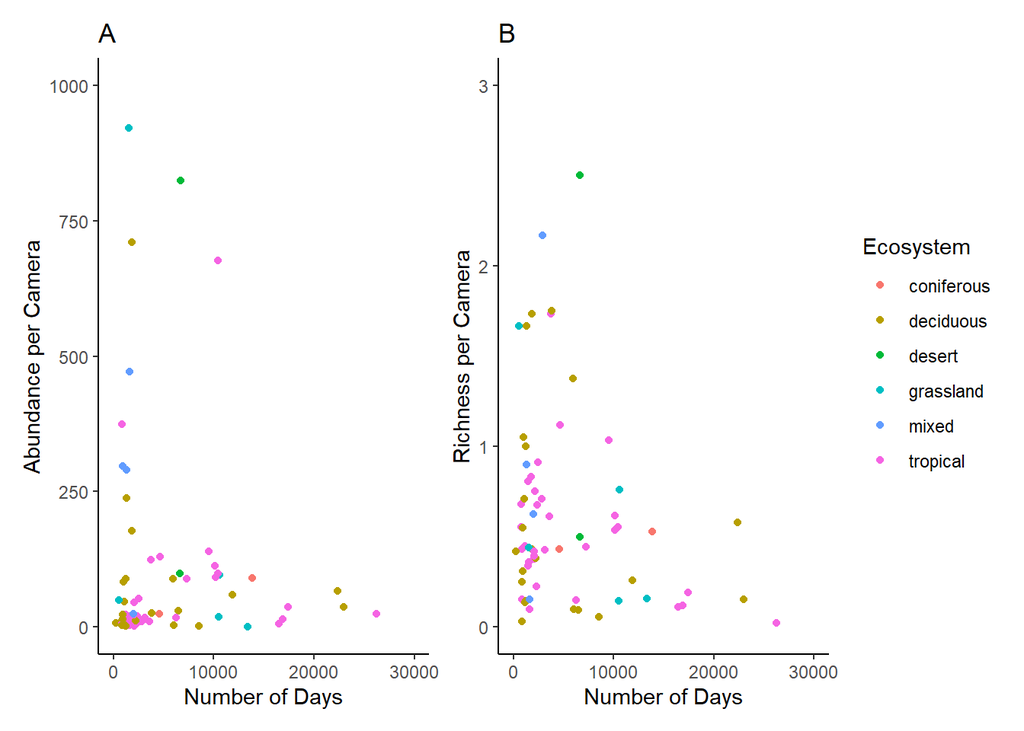

```r
#FIGURE 1 A AND B regression over days weighted by days
p1 <-ggplot(data_e3, aes(days, yi, weight = vi)) +
  geom_point(aes(color = ecosystem)) +
  labs(x = "Number of Days", y = "Abundance per Camera")+ theme_classic()+ labs(colour = "Ecosystem")+ xlim(0, 30000) + ylim (0, 1000) + theme(legend.position = "none") +  ggtitle('A')

p2 <-ggplot(data_e4, aes(days, yi, weight = vi)) +
  geom_point(aes(color = ecosystem)) +
  labs(x = "Number of Days", y = "Richness per Camera")+ theme_classic()+ labs(colour = "Ecosystem")+ xlim (0, 30000) + ylim (0,3)+ ggtitle('B')

library(patchwork)
p1 + p2
```

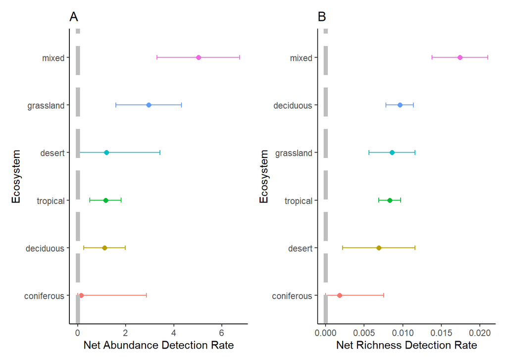

```r
#FIGURE 2 A AND B
data_model1_reorder <- transform(data_model, ecosystem = reorder(ecosystem, capture_rate))

data_model2_reorder <- transform(data_model, ecosystem = reorder(ecosystem, richness_rate))

p3 <-ggplot(data_model2_reorder, aes(ecosystem, richness_rate, color = factor(ecosystem))) +
  geom_point(size =2, order = order) +
  geom_errorbar(aes(ymin = ifelse(richness_rate - var_richnessrate <0,0, richness_rate-var_richnessrate), ymax = richness_rate + var_richnessrate), size= 0.5, width=0.1, position = position_dodge(width = 0.5)) +
  coord_flip() +
  geom_hline(yintercept = 0, colour="grey", linetype = "longdash", size = 2) +
  labs(x = "Ecosystem", y = "Net Richness Detection Rate") + theme_classic()+ ggtitle('B')+ theme(legend.position = "none")

p4 <-ggplot(data_model1_reorder, aes(ecosystem, capture_rate, color = factor(ecosystem))) +
  geom_point(size =2) +
  geom_errorbar(aes(ymin = ifelse(capture_rate - var_caprate <0,0, capture_rate-var_caprate), ymax= capture_rate + var_caprate), size= 0.5, width=0.1, position = position_dodge(width = 0.5)) +
  coord_flip() +
  geom_hline(yintercept = 0, colour="grey", linetype = "longdash", size = 2) +
  labs(x = "Ecosystem", y = "Net Abundance Detection Rate") + theme_classic()+ theme(legend.position = "none") + ggtitle('A')

p4+p3
```

### Meta models

Do a meta weighting captures by number of cameras over days. And richness by number of cams.

```r
library(broom)
library(tidymodels)

#models for the forest plots

#x = captures
#y = number of cams
#y = days

mod1.1 <- rma(yi = yi, sei = vi, method = "ML", mods = ~ecosystem -1, test = "knha", control=list(stepadj=0.5), data = data_e1)
summary(mod1.1)
```

```
##
## Mixed-Effects Model (k = 82; tau^2 estimator: ML)
##
##    logLik   deviance        AIC        BIC       AICc
## -222.6428  1762.6912   459.2855   476.1325   460.7990
##
## tau^2 (estimated amount of residual heterogeneity):     13.3616 (SE = 2.0867)
## tau (square root of estimated tau^2 value):             3.6553
## I^2 (residual heterogeneity / unaccounted variability): 100.00%
## H^2 (unaccounted variability / sampling variability):   125602917735.08
##
## Test for Residual Heterogeneity:
## QE(df = 76) = 4263163912.7004, p-val < .0001
##
## Test of Moderators (coefficients 1:6):
## F(df1 = 6, df2 = 76) = 4.8830, p-val = 0.0003
##
## Model Results:
##
##                      estimate      se    tval    pval    ci.lb   ci.ub
## ecosystemconiferous    0.1417  2.6849  0.0528  0.9580  -5.2057  5.4891
## ecosystemdeciduous     1.0125  0.7594  1.3333  0.1864  -0.5000  2.5250
## ecosystemdesert        1.1951  2.1922  0.5452  0.5872  -3.1710  5.5612
## ecosystemgrassland     2.9580  1.3424  2.2035  0.0306   0.2843  5.6317
## ecosystemmixed         6.8013  1.5501  4.3876  <.0001   3.7139  9.8886
## ecosystemtropical      1.0870  0.6160  1.7647  0.0816  -0.1398  2.3138
##
## ecosystemconiferous
## ecosystemdeciduous
## ecosystemdesert
## ecosystemgrassland     *
## ecosystemmixed       ***
## ecosystemtropical      .
##
## ---
## Signif. codes:  0 '***' 0.001 '**' 0.01 '*' 0.05 '.' 0.1 ' ' 1
```

```r
m1.1 <- tidy(mod1.1)
m1.1
```

```
## # A tibble: 6 x 6
##   term                type    estimate std.error statistic   p.value
##   <chr>               <chr>      <dbl>     <dbl>     <dbl>     <dbl>
## 1 ecosystemconiferous summary    0.142     2.68     0.0528 0.958
## 2 ecosystemdeciduous  summary    1.01      0.759    1.33   0.186
## 3 ecosystemdesert     summary    1.20      2.19     0.545  0.587
## 4 ecosystemgrassland  summary    2.96      1.34     2.20   0.0306
## 5 ecosystemmixed      summary    6.80      1.55     4.39   0.0000364
## 6 ecosystemtropical   summary    1.09      0.616    1.76   0.0816
```

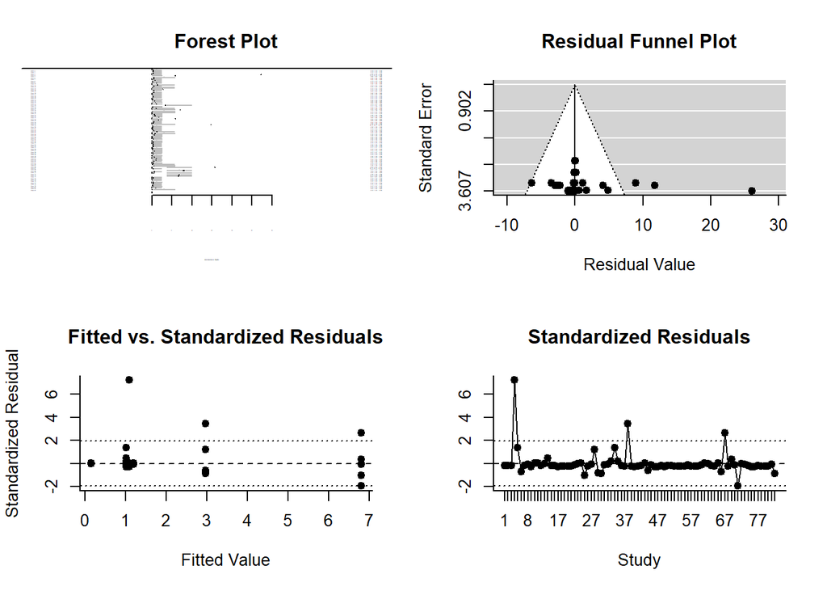

```r
plot(mod1.1)
```

```r
#x = richness
#y = number of cams
#y = days
mod1.2 <- rma(yi = yi, sei = vi, method = "ML", mods = ~ecosystem -1, test = "knha", control=list(stepadj=0.5), data = data_e2)#using ecosystem as a moderator
summary(mod1.2)
```

```
##
## Mixed-Effects Model (k = 81; tau^2 estimator: ML)
##
##    logLik   deviance        AIC        BIC       AICc
##  270.3039  1465.4415  -526.6078  -509.8467  -525.0736
##
## tau^2 (estimated amount of residual heterogeneity):     0.0001 (SE = 0.0000)
## tau (square root of estimated tau^2 value):             0.0088
## I^2 (residual heterogeneity / unaccounted variability): 100.00%
## H^2 (unaccounted variability / sampling variability):   10637275543.65
##
## Test for Residual Heterogeneity:
## QE(df = 75) = 1381336897.4210, p-val < .0001
##
## Test of Moderators (coefficients 1:6):
## F(df1 = 6, df2 = 75) = 14.7900, p-val < .0001
##
## Model Results:
##
##                      estimate      se    tval    pval    ci.lb   ci.ub
## ecosystemconiferous    0.0018  0.0063  0.2825  0.7784  -0.0108  0.0144
## ecosystemdeciduous     0.0104  0.0018  5.8472  <.0001   0.0069  0.0140
## ecosystemdesert        0.0069  0.0052  1.3454  0.1826  -0.0033  0.0172
## ecosystemgrassland     0.0086  0.0034  2.5522  0.0127   0.0019  0.0153
## ecosystemmixed         0.0153  0.0036  4.2010  <.0001   0.0081  0.0226
## ecosystemtropical      0.0077  0.0014  5.3384  <.0001   0.0048  0.0106
##
## ecosystemconiferous
## ecosystemdeciduous   ***
## ecosystemdesert
## ecosystemgrassland     *
## ecosystemmixed       ***
## ecosystemtropical    ***
##
## ---
## Signif. codes:  0 '***' 0.001 '**' 0.01 '*' 0.05 '.' 0.1 ' ' 1
```

```r
m1.2 <- tidy(mod1.2)
m1.2
```

```
## # A tibble: 6 x 6
##   term                type    estimate std.error statistic     p.value
##   <chr>               <chr>      <dbl>     <dbl>     <dbl>       <dbl>
## 1 ecosystemconiferous summary  0.00178   0.00632     0.282 0.778
## 2 ecosystemdeciduous  summary  0.0104    0.00179     5.85  0.000000122
## 3 ecosystemdesert     summary  0.00694   0.00516     1.35  0.183
## 4 ecosystemgrassland  summary  0.00862   0.00338     2.55  0.0127
## 5 ecosystemmixed      summary  0.0153    0.00365     4.20  0.0000724
## 6 ecosystemtropical   summary  0.00774   0.00145     5.34  0.000000964
```

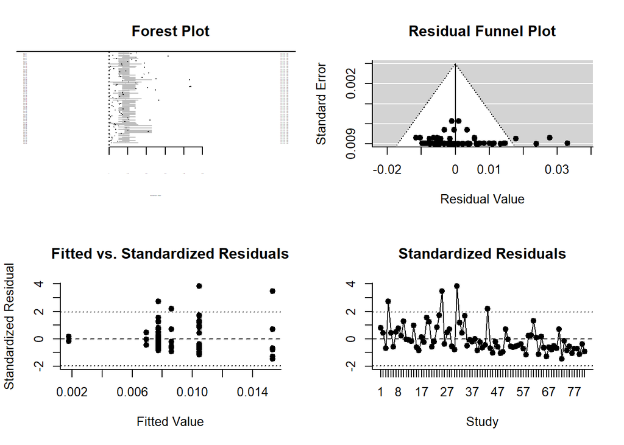

```r
plot(mod1.2)
```

```r
#regression models with days as a moderator

#abundance
mod2.1 <- rma(yi = yi, sei = vi, method = "ML", mods = ~days, test = "knha", control=list(stepadj=0.5), data = data_e3)
summary(mod2.1)
```

```
##
## Mixed-Effects Model (k = 71; tau^2 estimator: ML)
##
##    logLik   deviance        AIC        BIC       AICc
## -506.2095   891.3233  1018.4191  1025.2071  1018.7773
##
## tau^2 (estimated amount of residual heterogeneity):     72249.7652 (SE = 12268.7526)
## tau (square root of estimated tau^2 value):             268.7932
## I^2 (residual heterogeneity / unaccounted variability): 100.00%
## H^2 (unaccounted variability / sampling variability):   26961687.68
## R^2 (amount of heterogeneity accounted for):            0.00%
##
## Test for Residual Heterogeneity:
## QE(df = 69) = 586055.5049, p-val < .0001
##
## Test of Moderators (coefficient 2):
## F(df1 = 1, df2 = 69) = 0.0037, p-val = 0.9515
##
## Model Results:
##
##          estimate       se     tval    pval    ci.lb     ci.ub
## intrcpt  141.6745  45.1943   3.1348  0.0025  51.5144  231.8346  **
## days      -0.0003   0.0046  -0.0610  0.9515  -0.0095    0.0089
##
## ---
## Signif. codes:  0 '***' 0.001 '**' 0.01 '*' 0.05 '.' 0.1 ' ' 1
```

```r
m2.1 <- tidy(mod2.1)
m2.1
```

```
## # A tibble: 2 x 6
##   term      type      estimate std.error statistic p.value
##   <chr>     <chr>        <dbl>     <dbl>     <dbl>   <dbl>
## 1 intercept summary 142.        45.2        3.13   0.00253
## 2 days      summary  -0.000282   0.00463   -0.0610 0.952
```

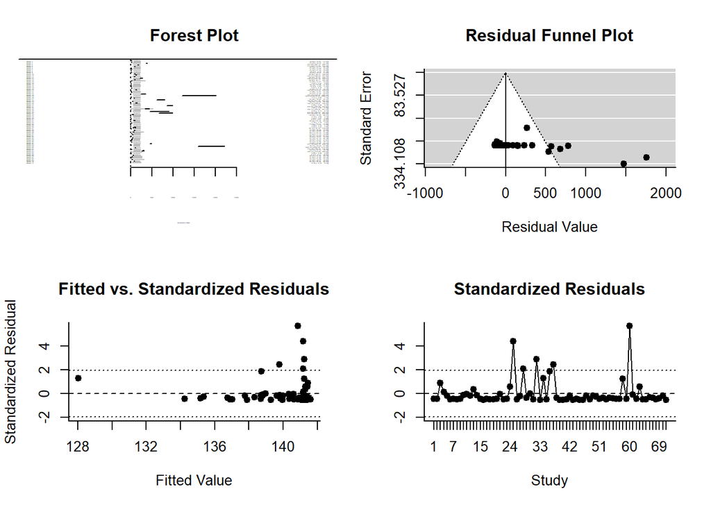

```r
plot(mod2.1)
```

```r
#richness
mod2.2 <- rma(yi = yi, sei = vi, method = "ML", mods = ~days, test = "knha", control=list(stepadj=0.5), data = data_e4)
summary(mod2.2)
```

```
##
## Mixed-Effects Model (k = 71; tau^2 estimator: ML)
##
##   logLik  deviance       AIC       BIC      AICc
## -77.1583  654.5599  160.3166  167.1046  160.6748
##
## tau^2 (estimated amount of residual heterogeneity):     0.4230 (SE = 0.0723)
## tau (square root of estimated tau^2 value):             0.6504
## I^2 (residual heterogeneity / unaccounted variability): 100.00%
## H^2 (unaccounted variability / sampling variability):   230449.46
## R^2 (amount of heterogeneity accounted for):            0.73%
##
## Test for Residual Heterogeneity:
## QE(df = 69) = 172482.2498, p-val < .0001
##
## Test of Moderators (coefficient 2):
## F(df1 = 1, df2 = 69) = 0.3698, p-val = 0.5451
##
## Model Results:
##
##          estimate      se     tval    pval    ci.lb   ci.ub
## intrcpt    0.7377  0.1076   6.8576  <.0001   0.5231  0.9523  ***
## days      -0.0000  0.0000  -0.6081  0.5451  -0.0000  0.0000
##
## ---
## Signif. codes:  0 '***' 0.001 '**' 0.01 '*' 0.05 '.' 0.1 ' ' 1
```

```r
m2.2 <- tidy(mod2.2)
m2.2
```

```
## # A tibble: 2 x 6
##   term      type       estimate std.error statistic       p.value
##   <chr>     <chr>         <dbl>     <dbl>     <dbl>         <dbl>
## 1 intercept summary  0.738      0.108         6.86  0.00000000241
## 2 days      summary -0.00000670 0.0000110    -0.608 0.545
```

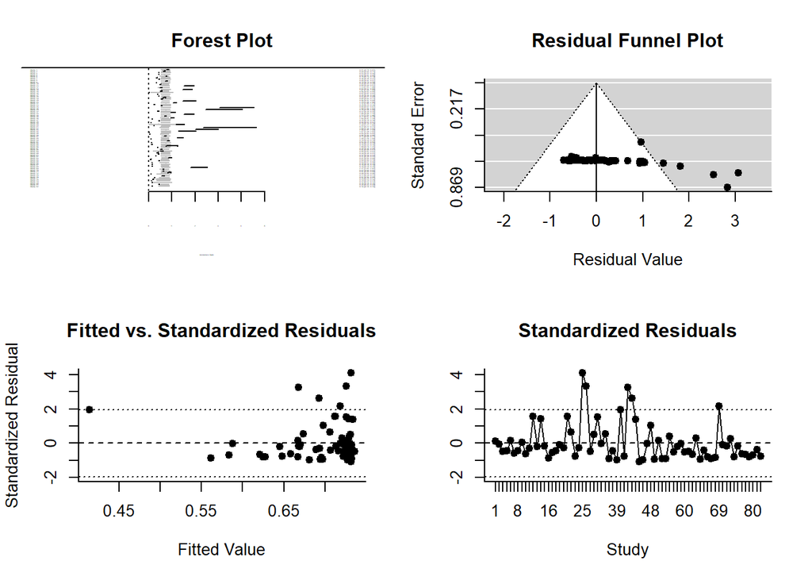

```r
plot (mod2.2)
```

## Viz

Need to weight points but sampling effort - n_cams/number of days for capture rate and richness. Then you can have an index that only has richness/n_cams or abundance/n_camps and regress that against days.

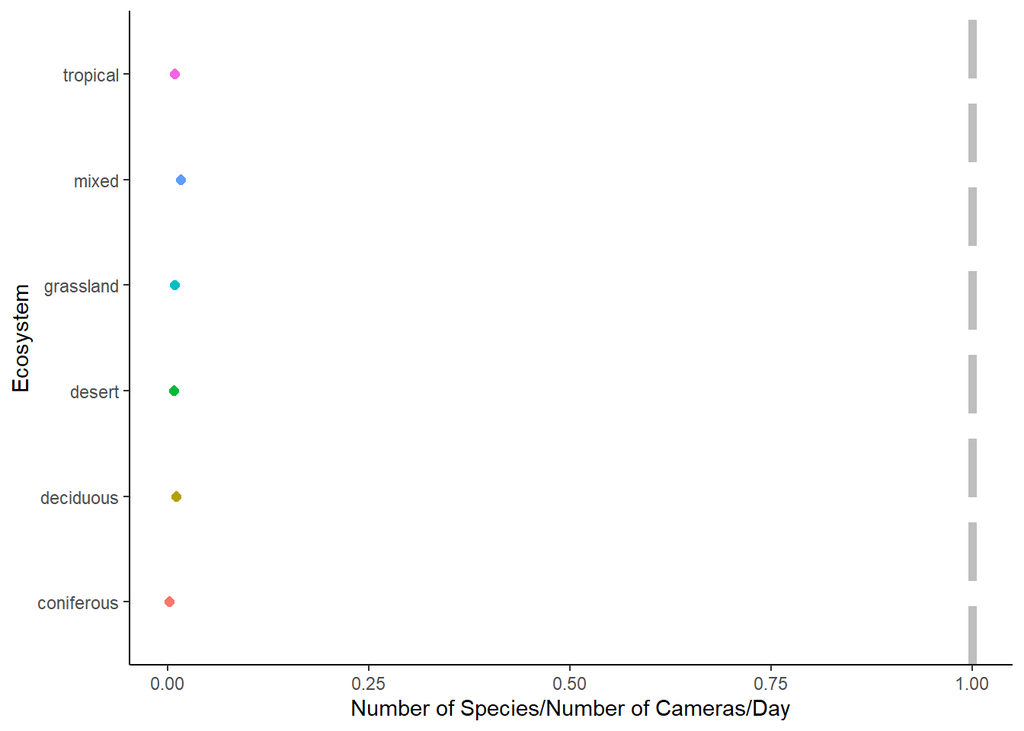

```r
#forest plots for indeces with days as a measure of sampling effort

ggplot(summary_data, aes(ecosystem, richness_rate, color = factor(ecosystem))) +
  geom_point(size =2) +
  geom_errorbar(aes(ymin = richness_rate - var_richnessrate, ymax = richness_rate + var_richnessrate), size= 0.7, width=0.1, position = position_dodge(width = 0.5)) +
  coord_flip() +
  geom_hline(yintercept = 1, colour="grey", linetype = "longdash", size = 2) +
  labs(x = "Ecosystem", y = "Number of Species/Number of Cameras/Day") + theme_classic()+ theme(legend.position = "none")
```

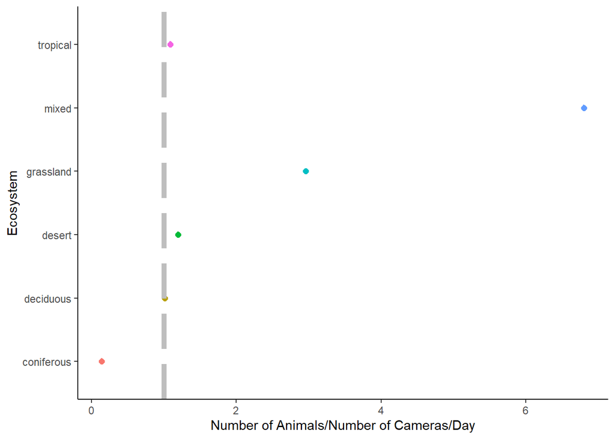

```r
ggplot(summary_data, aes(ecosystem, capture_rate, color = factor(ecosystem))) +
  geom_point(size =2) +
  geom_errorbar(aes(ymin = capture_rate - var_caprate, ymax = capture_rate + var_caprate), size= 0.5, width=0.1, position = position_dodge(width = 0.5)) +
  coord_flip() +
  geom_hline(yintercept = 1, colour="grey", linetype = "longdash", size = 2) +
  labs(x = "Ecosystem", y = "Number of Animals/Number of Cameras/Day") + theme_classic()+ theme(legend.position = "none")#variance is too small to see
```

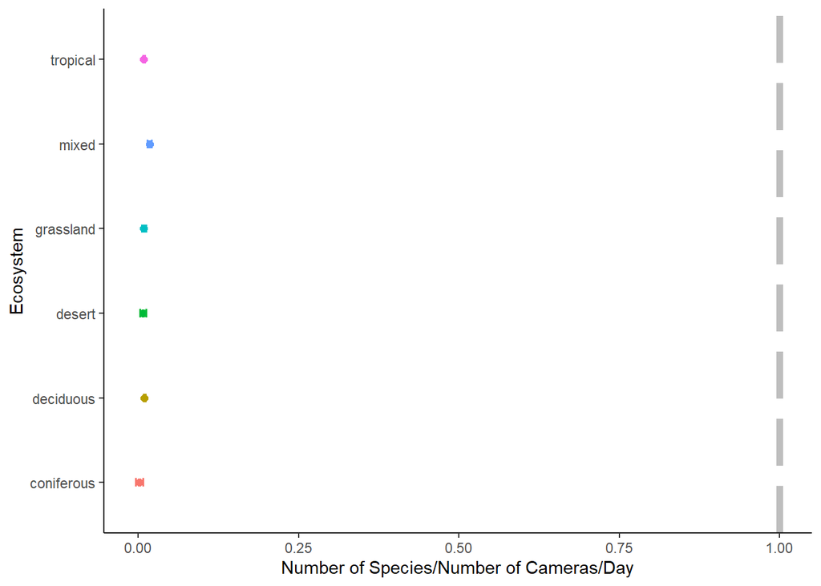

```r
#let's try forst plot with model estimates instead

ggplot(data_model, aes(ecosystem, richness_rate, color = factor(ecosystem))) +
  geom_point(size =2) +
  geom_errorbar(aes(ymin = richness_rate - var_richnessrate, ymax = richness_rate + var_richnessrate), size= 0.7, width=0.1, position = position_dodge(width = 0.5)) +
  coord_flip() +
  geom_hline(yintercept = 1, colour="grey", linetype = "longdash", size = 2) +
  labs(x = "Ecosystem", y = "Number of Species/Number of Cameras/Day") + theme_classic()+ theme(legend.position = "none")
```

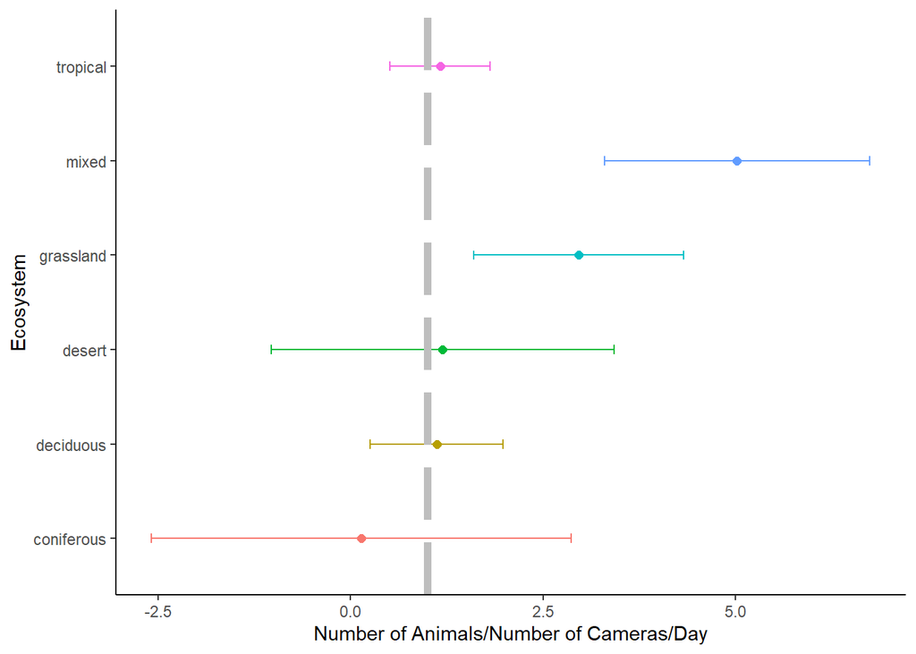

```r
ggplot(data_model, aes(ecosystem, capture_rate, color = factor(ecosystem))) +
  geom_point(size =2) +
  geom_errorbar(aes(ymin = capture_rate - var_caprate, ymax = capture_rate + var_caprate), size= 0.5, width=0.1, position = position_dodge(width = 0.5)) +
  coord_flip() +
  geom_hline(yintercept = 1, colour="grey", linetype = "longdash", size = 2) +
  labs(x = "Ecosystem", y = "Number of Animals/Number of Cameras/Day") + theme_classic()+ theme(legend.position = "none")
```

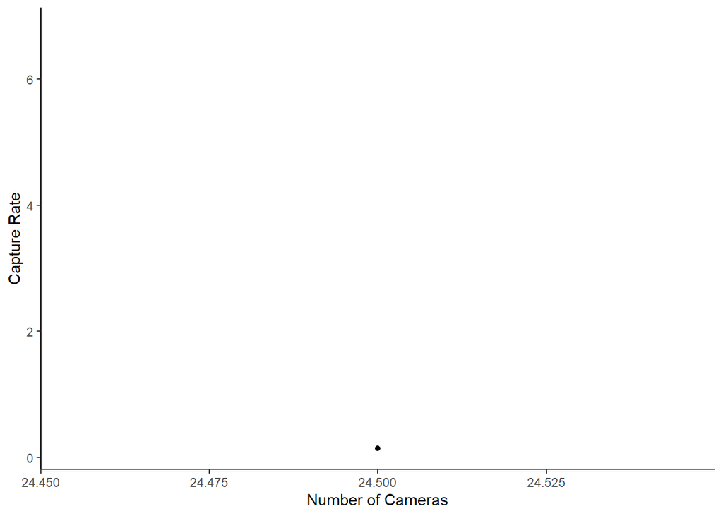

```r
ggplot(summary_data, aes(n_cams, capture_rate)) +
  geom_point() +
  stat_smooth(method = "lm", formula = y ~ x + I(x^2), size = 2, color = "black", size = 2, se = FALSE)+ theme_classic()+ xlab("Number of Cameras")+ ylab ("Capture Rate")
```

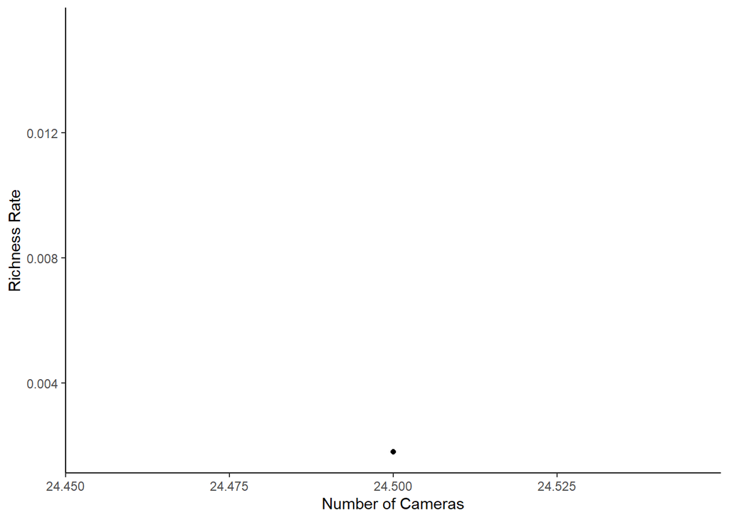

```r
ggplot(summary_data, aes(n_cams, richness_rate)) +
  geom_point() +
  stat_smooth(method = "lm", formula = y ~ x + I(x^2), size = 2, color = "black", size = 2, se = FALSE)+ theme_classic()+ xlab("Number of Cameras")+ ylab ("Richness Rate")
```

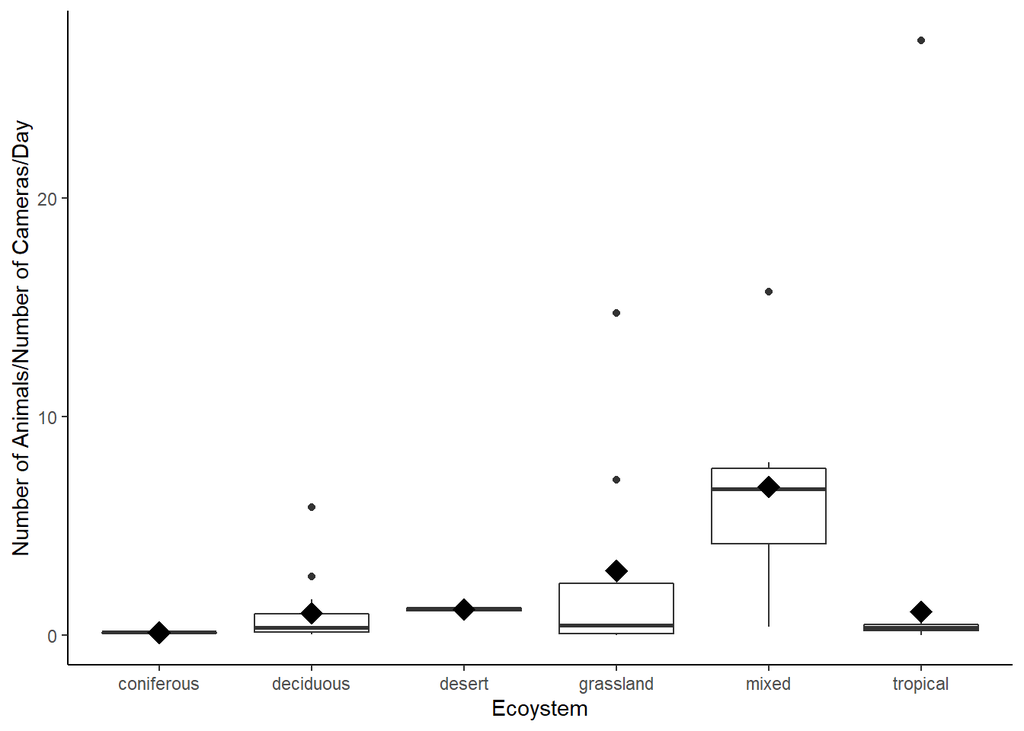

```r
#distribution of n_cam rates
ggplot(data_e1, aes(ecosystem, yi)) +
  geom_boxplot() +
  labs(x = "Ecoystem", y = "Number of Animals/Number of Cameras/Day") +
  stat_summary(fun.y=mean, geom="point", shape=18, size = 5, color="black", fill="red") + theme_classic()
```

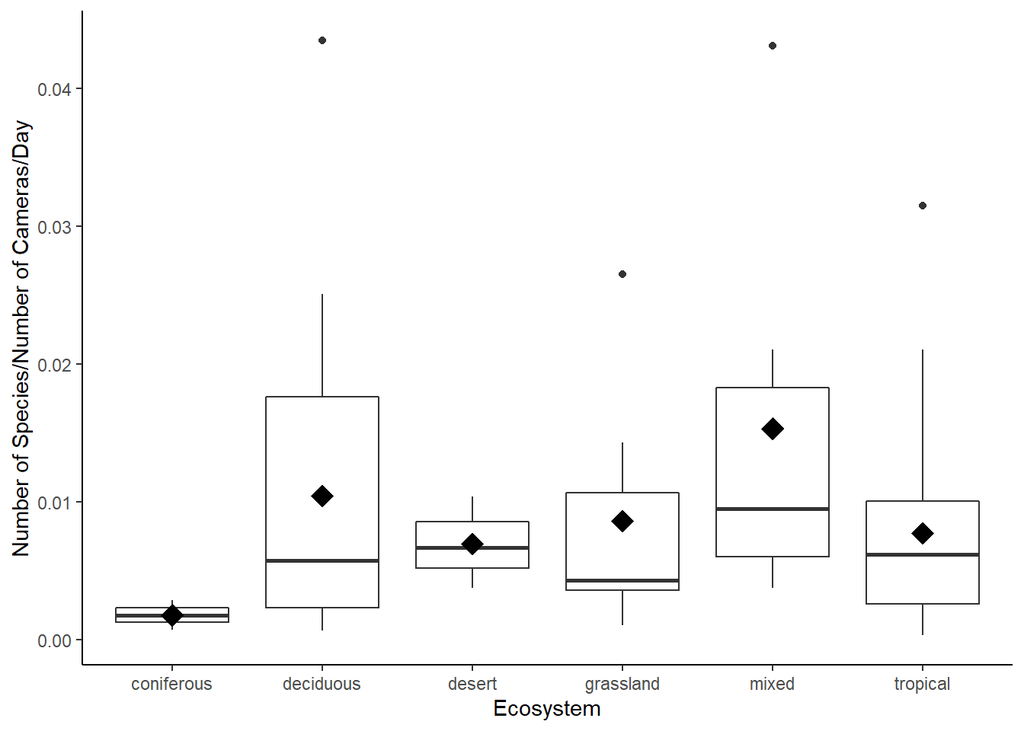

```r
ggplot(data_e2, aes(ecosystem, yi)) +
  geom_boxplot() +
  labs(x = "Ecosystem", y = "Number of Species/Number of Cameras/Day") +
  stat_summary(fun.y=mean, geom="point", shape=18, size = 5, color="black", fill="red") + theme_classic()
```

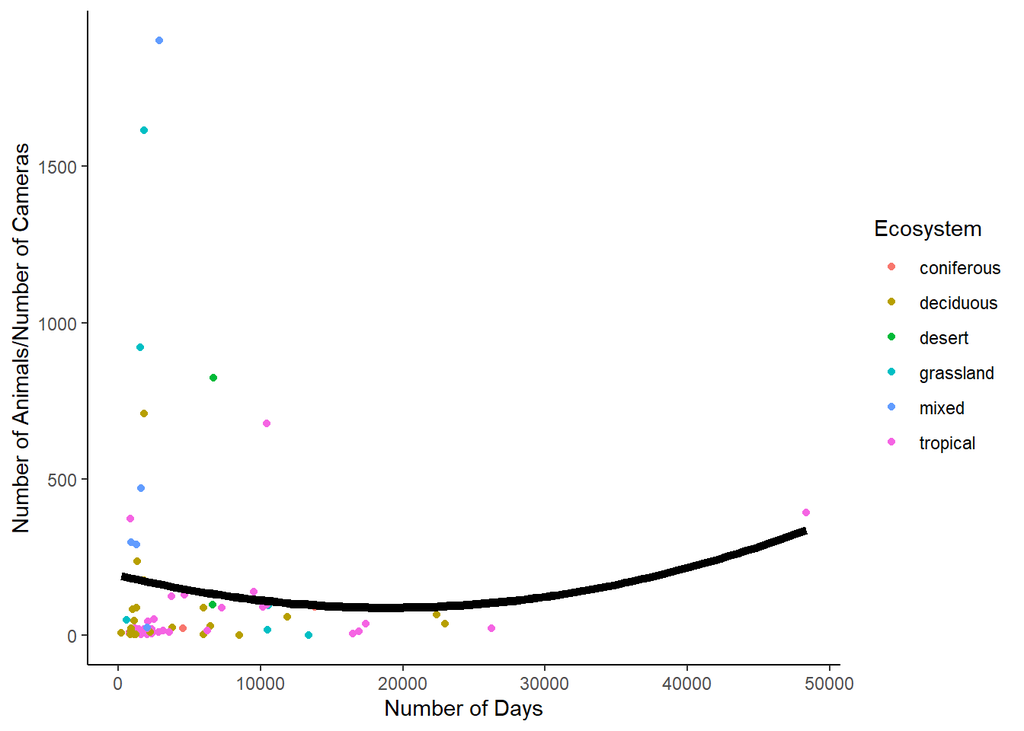

```r
#cams as sampling effort
ggplot(data_e3, aes(days, yi)) +
  geom_point(aes(color = ecosystem)) +
  stat_smooth(method = "lm", formula = y ~ x + I(x^2), size = 2, color = "black", se = FALSE) +
  labs(x = "Number of Days", y = "Number of Animals/Number of Cameras")+ theme_classic()+ labs(colour = "Ecosystem")
```

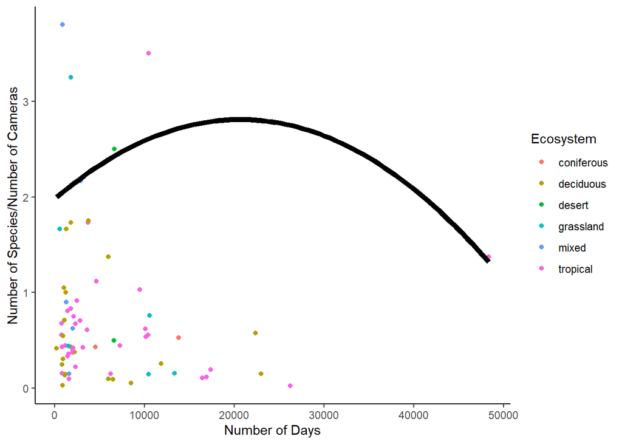

```r
ggplot(data_e4, aes(days, yi, weight = vi)) +
  geom_point(aes(color = ecosystem)) +
  stat_smooth(method = "lm", formula = y ~ x + I(x^2), size = 2, color = "black", size = 2, se = FALSE) +
  labs(x = "Number of Days", y = "Number of Species/Number of Cameras")+ theme_classic()+ labs(colour = "Ecosystem")
```

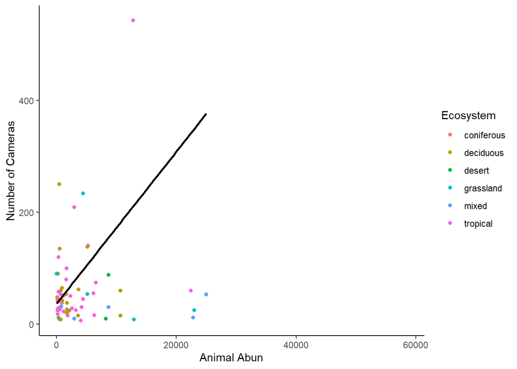

```r
ggplot(data, aes(captures, n_cams)) +
  geom_point(aes(color = ecosystem)) +
  stat_smooth(method = "lm", mapping = aes(weight = days), size = 1, color = "black", se = FALSE) +
  labs(x = "Animal Abun", y = "Number of Cameras")+ theme_classic()+ labs(colour = "Ecosystem")
```

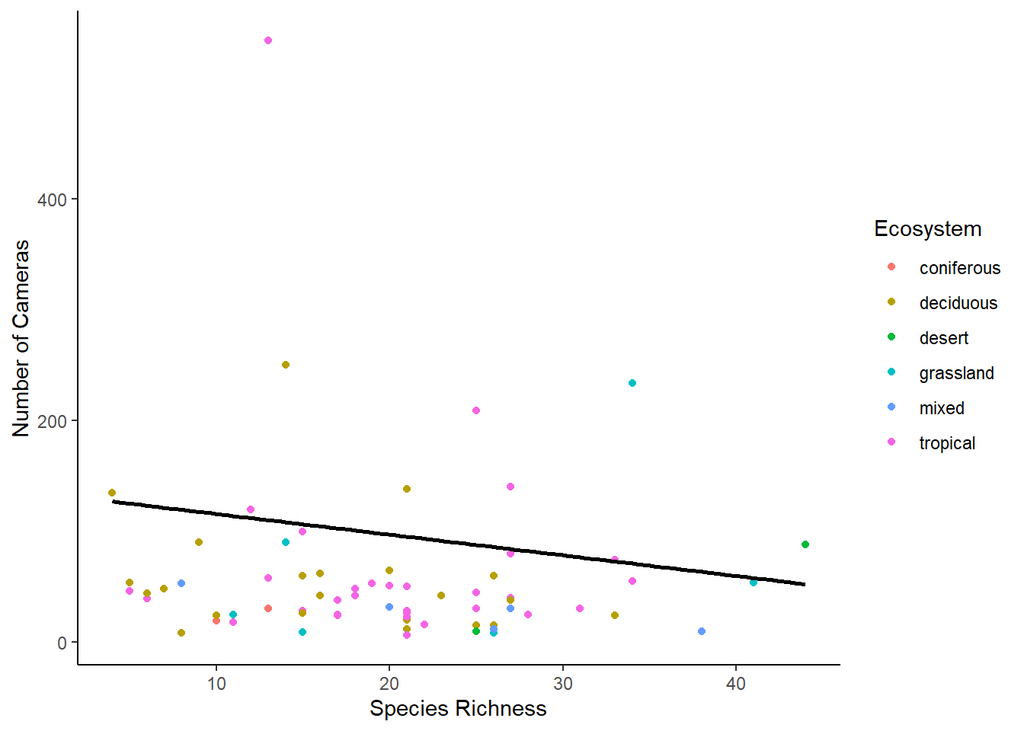

```r
ggplot(data, aes(richness, n_cams)) +
  geom_point(aes(color = ecosystem)) +
  stat_smooth(method = "lm", mapping = aes(weight = days), size = 1, color = "black", se = FALSE) +
  labs(x = "Species Richness", y = "Number of Cameras")+ theme_classic()+ labs(colour = "Ecosystem")
```

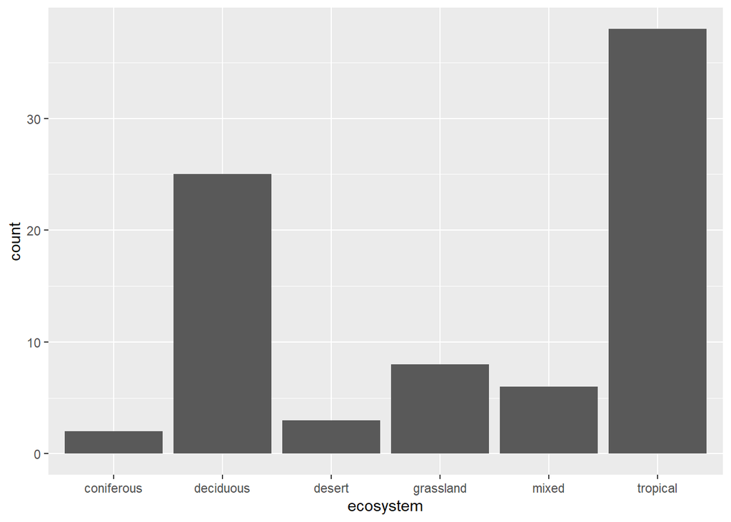

```r
ggplot(data, aes(ecosystem)) + geom_bar()#rough frequency per study plot
```

```r
table (data$ecosystem)
```

```
##
## coniferous  deciduous     desert  grassland      mixed   tropical
##          2         25          3          8          6         38
```